# resolução lab 2

Luiz Fonseca

18 de novembro de 2017

Antes de começar vamos ver os valores faltantes

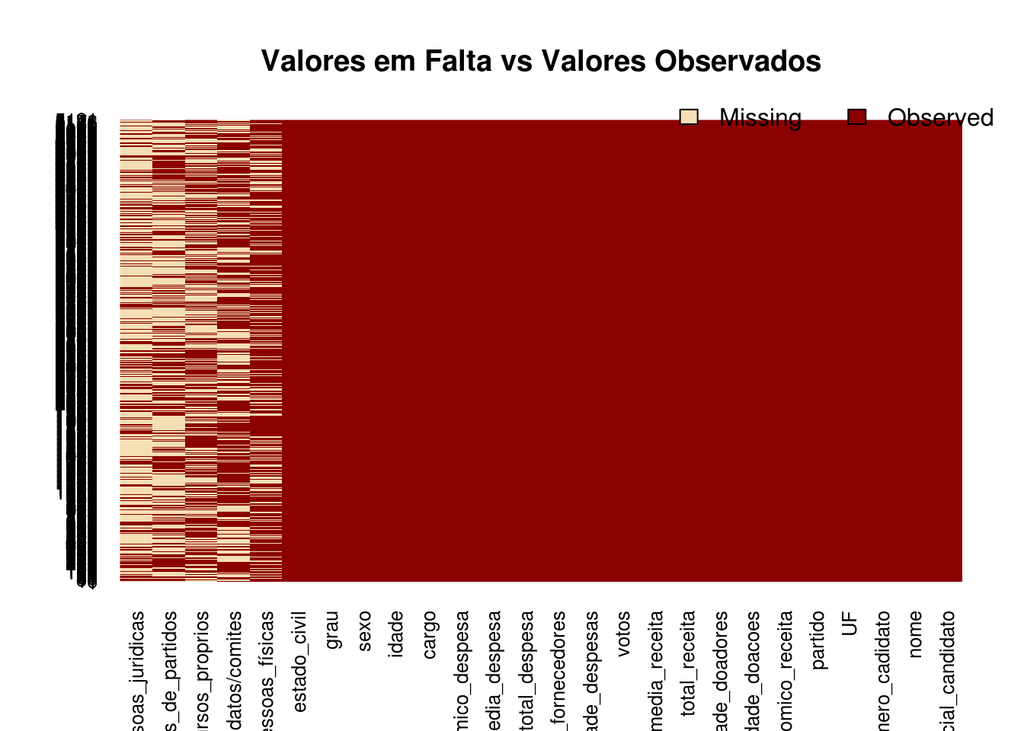

```r
library(tidyverse)
library(Amelia)
library(reshape2)
dadosEleicoes <- read_csv("~/Faculdade/data-science-2017.2/dadosEleicoes.csv",
                          col_types = cols(numero_cadidato = col_character(),
                                           sequencial_candidato = col_character()))


missmap(dadosEleicoes, main = "Valores em Falta vs Valores Observados")
```

Vemos que em 5 variáveis, há muitos valores faltantes. Vamos excluir essas variáveis.

```r
dados.modelo <- dadosEleicoes %>%
  select(-`recursos_de_outros_candidatos/comites`, -recursos_de_partidos, -recursos_de_pessoas_juridicas, -recursos_de_pessoas_físicas, -recursos_proprios,
         -cargo, -sequencial_candidato, -numero_cadidato, -setor_economico_receita,
         -setor_economico_despesa, -nome)
```

# Um modelo de regressão múltipla com todas as variáveis é plausível para explicar a variação em y (votos)? Em que grau?

```r
model.fit <- lm(formula = votos ~ ., dados.modelo, na.action = na.omit)
summary(model.fit)
```

```
##
## Call:
## lm(formula = votos ~ ., data = dados.modelo, na.action = na.omit)
##
## Residuals:
##     Min      1Q  Median      3Q     Max
## -216508   -7939   -2288    2979 1383130
##
## Coefficients:
##                                         Estimate Std. Error t value
## (Intercept)                           -1.171e+04  6.345e+03  -1.845
## UFAL                                   1.085e+04  6.081e+03   1.783
## UFAM                                   1.482e+04  6.306e+03   2.350
## UFAP                                   5.221e+03  5.891e+03   0.886
## UFBA                                   1.712e+04  5.236e+03   3.270
## UFCE                                   1.944e+04  5.408e+03   3.594
## UFDF                                   7.080e+03  5.683e+03   1.246
## UFES                                   1.221e+04  5.553e+03   2.199
## UFGO                                   1.023e+04  6.167e+03   1.659
## UFMA                                   1.732e+04  5.488e+03   3.155
## UFMG                                   1.135e+04  4.955e+03   2.290
## UFMS                                   2.423e+03  5.730e+03   0.423
## UFMT                                   8.042e+03  6.078e+03   1.323
## UFPA                                   2.110e+04  5.472e+03   3.856
## UFPB                                   1.985e+04  6.088e+03   3.260
## UFPE                                   1.803e+04  5.683e+03   3.173
## UFPI                                   1.334e+04  6.144e+03   2.171
## UFPR                                   1.354e+04  5.192e+03   2.607
## UFRJ                                   9.261e+03  4.872e+03   1.901
## UFRN                                   1.642e+04  6.204e+03   2.646
## UFRO                                   3.871e+03  6.206e+03   0.624
## UFRR                                   4.082e+03  6.110e+03   0.668
## UFRS                                   1.597e+04  5.160e+03   3.095
## UFSC                                   1.761e+04  5.743e+03   3.067
## UFSE                                   1.626e+04  6.329e+03   2.568
## UFSP                                   1.304e+04  4.828e+03   2.702
## UFTO                                   8.107e+03  7.036e+03   1.152
## partidoPCB                            -5.800e+03  6.826e+03  -0.850
## partidoPC do B                        -7.749e+03  5.124e+03  -1.512
## partidoPCO                            -4.846e+03  1.252e+04  -0.387
```

[output cut: 118 more lines]

```
## grauENSINO MÉDIO COMPLETO             0.854797
## grauENSINO MÉDIO INCOMPLETO           0.727103
## grauLÊ E ESCREVE                      5.52e-06 ***
## grauSUPERIOR COMPLETO                 0.113488
## grauSUPERIOR INCOMPLETO               0.626479
## estado_civilDIVORCIADO(A)             0.727361
## estado_civilSEPARADO(A) JUDICIALMENTE 0.105043
## estado_civilSOLTEIRO(A)               0.363328
## estado_civilVIÚVO(A)                  0.086300 .
## ---
## Signif. codes:  0 '***' 0.001 '**' 0.01 '*' 0.05 '.' 0.1 ' ' 1
##
## Residual standard error: 34170 on 5113 degrees of freedom
## Multiple R-squared:  0.4427, Adjusted R-squared:  0.4343
## F-statistic: 52.75 on 77 and 5113 DF,  p-value: < 2.2e-16
```

Alguns p-valores estão altos e outros estão bem baixos, ou seja, algumas variáveis podem ser consideradas boas preditoras.

# Todas as variáveis são úteis para o modelo de regressão?

Existem vários algoritmos de seleção de váriáveis: forward selection, backward selection, mixed selection, busca exaustiva, entre outros. O método que será utilizado é o forward selection.

# Se a resposta para a pergunta anterior foi não, construa um novo modelo sem essas variáveis e o compare ao modelo com todas as variáveis (e.g. em termos de R2 e RSE).

```r
variaveis.selecionadas <- dados.modelo %>%
  select(votos, quantidade_doacoes, quantidade_doadores, total_receita, media_receita,
         quantidade_despesas, quantidade_fornecedores, total_despesa, media_despesa, sexo,
         grau)

best.model <- lm(formula = votos ~ ., variaveis.selecionadas, na.action = na.omit)
summary(best.model)
```

```
##
## Call:
## lm(formula = votos ~ ., data = variaveis.selecionadas, na.action = na.omit)
##
## Residuals:
##     Min      1Q  Median      3Q     Max
## -227939   -6198   -2505     892 1389795
##
## Coefficients:
##                                     Estimate Std. Error t value Pr(>|t|)
## (Intercept)                       -4.326e+03  2.235e+03  -1.935 0.053052
## quantidade_doacoes                 1.020e+02  2.456e+01   4.154 3.32e-05
## quantidade_doadores                1.208e+02  3.325e+01   3.632 0.000284
## total_receita                      4.386e-02  7.845e-03   5.591 2.38e-08
## media_receita                      4.907e-01  4.815e-02  10.192  < 2e-16
## quantidade_despesas                4.300e+01  3.634e+00  11.831  < 2e-16
## quantidade_fornecedores           -5.081e+01  5.252e+00  -9.675  < 2e-16
## total_despesa                     -2.525e-02  7.528e-03  -3.354 0.000803
## media_despesa                      1.885e+00  3.553e-01   5.306 1.17e-07
## sexoMASCULINO                      4.136e+03  1.089e+03   3.796 0.000149
## grauENSINO FUNDAMENTAL INCOMPLETO -9.083e+01  3.704e+03  -0.025 0.980436
## grauENSINO MÉDIO COMPLETO          8.045e+02  2.295e+03   0.351 0.725908
## grauENSINO MÉDIO INCOMPLETO        1.495e+03  3.736e+03   0.400 0.689122
## grauLÊ E ESCREVE                   2.997e+04  6.520e+03   4.597 4.39e-06
## grauSUPERIOR COMPLETO              4.072e+03  2.188e+03   1.861 0.062786
## grauSUPERIOR INCOMPLETO           -7.448e+02  2.538e+03  -0.293 0.769195
##
## (Intercept)                       .
## quantidade_doacoes                ***
## quantidade_doadores               ***
## total_receita                     ***
## media_receita                     ***
## quantidade_despesas               ***
## quantidade_fornecedores           ***
## total_despesa                     ***
## media_despesa                     ***
## sexoMASCULINO                     ***
## grauENSINO FUNDAMENTAL INCOMPLETO
## grauENSINO MÉDIO COMPLETO
## grauENSINO MÉDIO INCOMPLETO
## grauLÊ E ESCREVE                  ***
## grauSUPERIOR COMPLETO             .
## grauSUPERIOR INCOMPLETO
## ---
## Signif. codes:  0 '***' 0.001 '**' 0.01 '*' 0.05 '.' 0.1 ' ' 1
##
## Residual standard error: 34400 on 5175 degrees of freedom
## Multiple R-squared:  0.4282, Adjusted R-squared:  0.4265
## F-statistic: 258.3 on 15 and 5175 DF,  p-value: < 2.2e-16
```

O r² deu menor mais isso ja era esperado. Quanto mais variaveis mais o modelo se ajusta aos dados de treino, mas não necessariamente aos dados de teste.

# Analise os plots de resíduos de cada variável e veja se algum (um ou mais) deles indica não aleatoriedade dos erros.

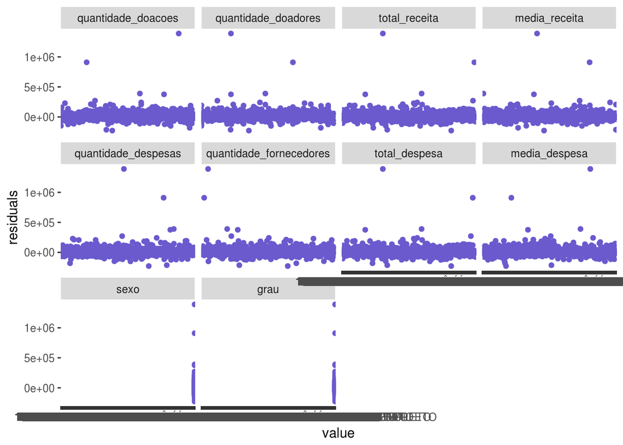

```r
variaveis.selecionadas <- na.omit(variaveis.selecionadas)
variaveis.selecionadas$residuals <- residuals(best.model)

variable.names <- c(names(variaveis.selecionadas)[2:11], "residuals")
plotDF <- melt(variaveis.selecionadas[, variable.names], id="residuals")

ggplot(plotDF, aes(x=value, y=residuals)) +
  geom_point(color="slateblue") + facet_wrap(~ variable)
```